# Assignment 7

Sean Leggett - BDA201 Winter 2020 March 21, 2020

## Question

There is a cleaning company that offers cleaning services to other businesses. The company contracts to clean office space in increments of 100 square feet. The business determines its margins by determining how long it takes a crew to clean 100 square feet of office space and bases its rates on this information.

## Answer

We considered analysis outside the perspective of normal distribution to be outside the scope of this assignment.

Let’s begin by assessing mean and standard deviation of the data collected:

```r
collection <- data.frame("Hours" = c(5.5, 6.9, 5.8, 5.5, 4.5, 4.6, 7.8, 6.4, 5.6, 7.4, 4, 4.5))
collmean <- mean(collection$Hours)
collsd <- sd(collection$Hours)
collmean
```

```
[1] 5.708333
```

```r
collsd
```

```
[1] 1.217642
```

We would prefer to visual confirm standar deviation…

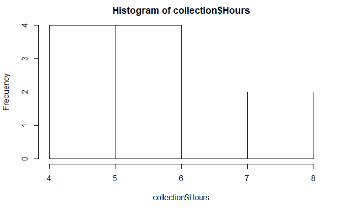

```r
collhist <- hist(collection$Hours)
```

```r
collhist
```

```
$breaks
[1] 4 5 6 7 8

$counts
[1] 4 4 2 2

$density
[1] 0.3333333 0.3333333 0.1666667 0.1666667

$mids
[1] 4.5 5.5 6.5 7.5

$xname
[1] "collection$Hours"

$equidist
[1] TRUE

attr(,"class")
[1] "histogram"
```

We do not find this to be a comforting distribution. Outliers certainly affect the variable distribution. In this case, it could be down to different types of spaces. 100sqft of doctor’s office is different to 100sqft of lawyer’s office. However, we accept the data as reported.

Firstly, we would like to establish the boundaries around existing sample of 12 for comparison.

```r
x <- 5.5
z_score <- qnorm(.990) ##qnorm of ..990 for 98% confidence
n <- 12 ## number of results in sample
s <- 1.2 ## standard deviation of results

lower_bound <- x - z_score * s/sqrt(n)
lower_bound
```

```
[1] 4.694129
```

```r
upper_bound <- x + z_score * s/sqrt(n)
upper_bound
```

```
[1] 6.305871
```

Which means, with the 12 result sample, 98% of the time, the hours required to clean 100 sq ft of office space would be between 4.7 hours and 6.3 hours. An interval of 1.6 hours. Not particularly narrow.

Now, let’s repeat the exercise using 7 results to establish the confidence interval, assuming that standard deviation and sample mean have not changed…

```r
x <- 5.5
z_score <- qnorm(.990) ##qnorm of ..990 for 98% confidence
n <- 7 ## number of results in sample
s <- 1.2 ## standard deviation of results

lower_bound <- x - z_score * s/sqrt(n)
lower_bound
```

```
[1] 4.444868
```

```r
upper_bound <- x + z_score * s/sqrt(n)
upper_bound
```

```
[1] 6.555132
```

Using 7 data points from the sample the results are 98% of the time, it will take between 4.4 and 6.6 hours to clean 100 square feet of office space. An interval even wider than with 12 points of data considered. Clearly, up to perhaps an unknown quantity, more data points in the sample yield a narrower confidence interval.

Increasing the confidence interval to 99% we find the following:

```r
x <- 5.5
z_score <- qnorm(.995) ##qnorm of ..995 for 99% confidence
n <- 7 ## number of results in sample
s <- 1.2 ## standard deviation of results

lower_bound <- x - z_score * s/sqrt(n)
lower_bound
```

```
[1] 4.331714
```

```r
upper_bound <- x + z_score * s/sqrt(n)
upper_bound
```

```
[1] 6.668286
```

Therefore, 99% of the time, it will take between 4.3 hours and 6.7 hours to clean 100 squre feet of office space. A confidence interval of 2.4 hours which is a substanial range. With limited sample space and with such a high requirement for the confidence interval (99%) we are not surprised to see quite a broad range in the actual range in the confidence interval.